# Лабораторная работа № 2

Настройка DNS-сервера

Павличенко Родион Андреевич

1132246838@rudn.ru

Российский университет дружбы народов им. Патриса Лумумбы

2026-09-17

# Информация

## Докладчик

- Павличенко Родион Андреевич
- Студент
- Группа НПИбд-02-24
- Российский университет дружбы народов им. Патриса Лумумбы
- 1132246838@rudn.ru

# Цель и задание

## Цель работы

Получить практические навыки установки и настройки DNS-сервера BIND, создания прямой и обратной зон, проверки разрешения доменных имён и автоматизации конфигурации серверной виртуальной машины средствами Vagrant.

## Основные задачи

- установить и настроить BIND;
- создать прямую и обратную зоны;
- настроить NetworkManager, firewalld и SELinux;
- проверить DNS с помощью `dig` и `host`;
- автоматизировать настройку в Vagrant.

# Выполнение лабораторной работы

## Подготовка виртуальной машины

Запущена виртуальная машина `server`.

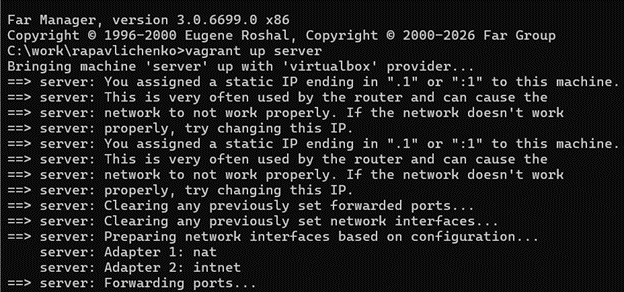

Выполнено подключение по SSH.

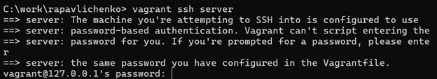

## Переход к административной работе

Выполнен вход под пользователем `rapavlichenko`.

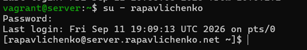

Получены полномочия суперпользователя.

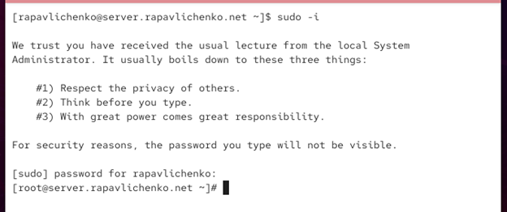

## Установка BIND

Установлены пакеты `bind` и `bind-utils`, содержащие DNS-сервер и диагностические утилиты.

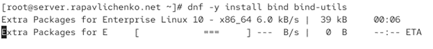

## Проверка исходной работы DNS

Команда `dig` вернула A-записи внешнего узла. Одновременно выявлен недоступный DNS-сервер `172.19.0.2`.

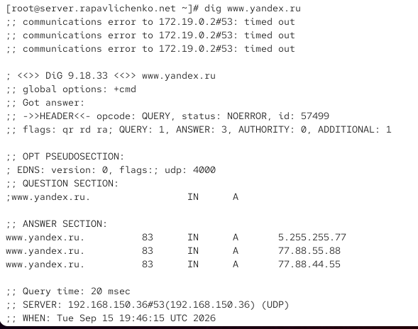

## Основные файлы конфигурации

`/etc/resolv.conf` задаёт используемые DNS-серверы.

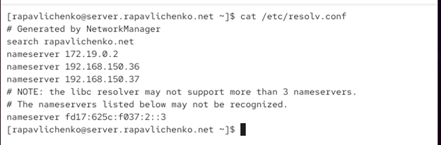

`/etc/named.conf` задаёт параметры BIND.

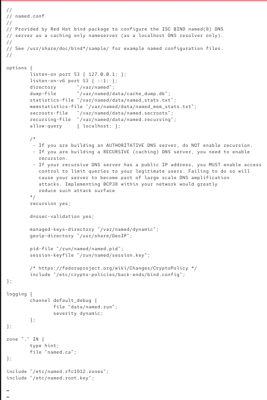

## Шаблоны файлов зон

Шаблон прямой локальной зоны.

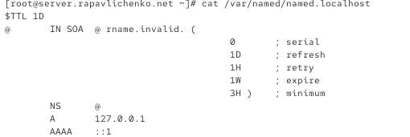

Шаблон обратной локальной зоны.

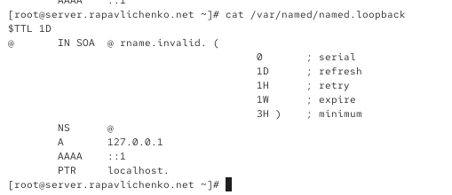

## Корневые DNS-серверы

Файл `named.ca` содержит адреса корневых DNS-серверов, с которых начинается рекурсивное разрешение имён.

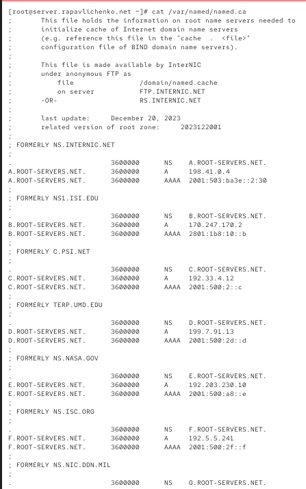

## Первый запуск и диагностика

Служба `named` была запущена.

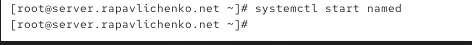

Проверка показала, что локальный DNS ещё не используется системой.

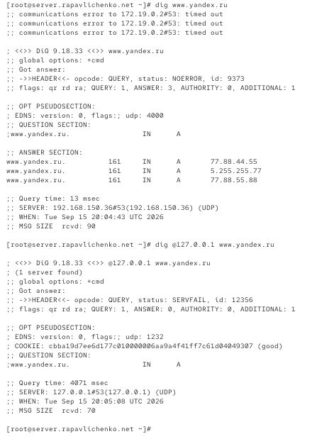

## Открытие профиля eth0

Запущен интерактивный редактор NetworkManager.

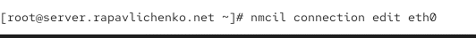

Выбран профиль подключения `eth0`.

## Изменение DNS в NetworkManager

Удалены автоматически полученные DNS-серверы, включён `ignore-auto-dns` и задан адрес `127.0.0.1`.

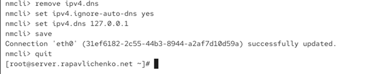

## Настройка локального DNS

Для профиля `eth0` отключено получение DNS по DHCP и задан локальный сервер `127.0.0.1`.

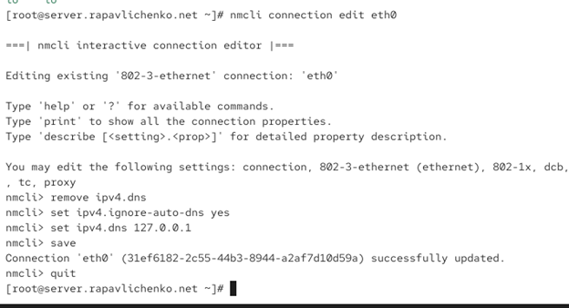

## Проверка resolv.conf

После перезапуска NetworkManager локальный DNS-сервер появился в `/etc/resolv.conf`.

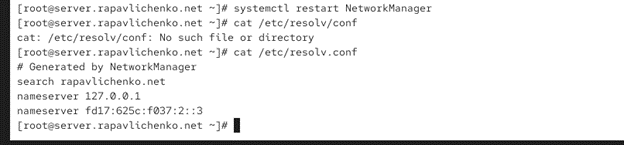

## Настройка BIND и firewalld

Разрешены запросы из локальной сети.

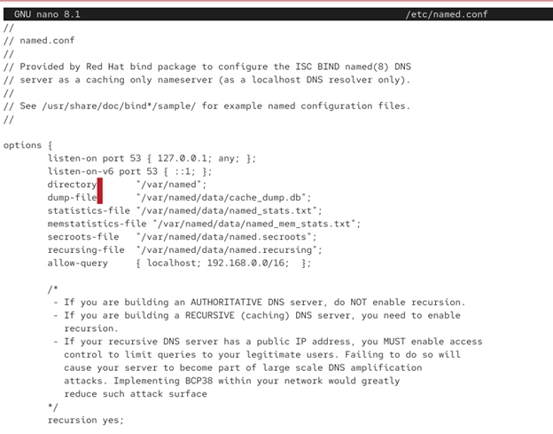

В firewalld разрешена служба DNS.

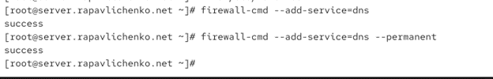

## Проверка сетевого порта

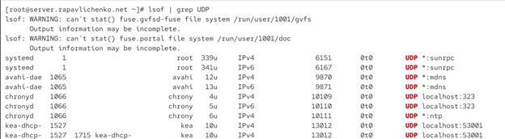

## Подготовка пользовательского файла зон

Скопирован файл примеров зон.

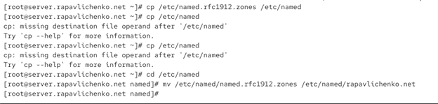

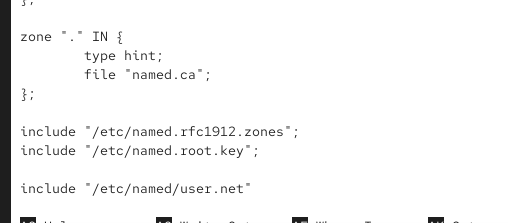

## Описание зон

В конфигурацию подключены прямая зона `rapavlichenko.net` и обратная зона `1.168.192.in-addr.arpa`.

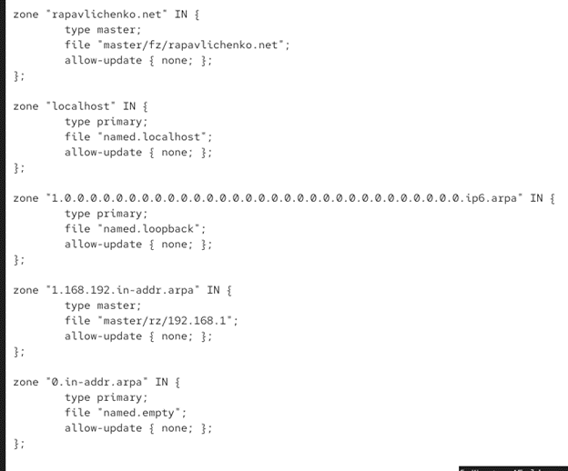

## Каталоги файлов зон

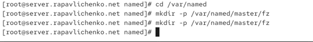

## Подготовка прямой зоны

Шаблон `named.localhost` скопирован в каталог прямых зон и переименован в `rapavlichenko.net`.

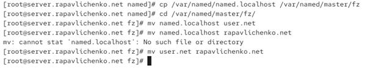

## Прямая зона

Созданы SOA- и NS-записи, а также A-записи узлов `server` и `ns` с адресом `192.168.1.1`.

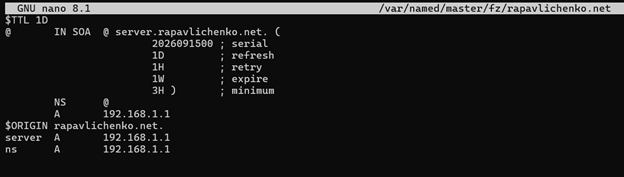

## Подготовка обратной зоны

Шаблон `named.loopback` скопирован в каталог обратных зон и переименован в `192.168.1`.

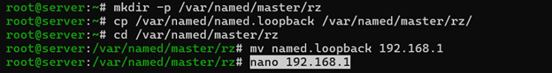

## Обратная зона

PTR-записи связывают адрес `192.168.1.1` с именами `server.rapavlichenko.net` и `ns.rapavlichenko.net`.

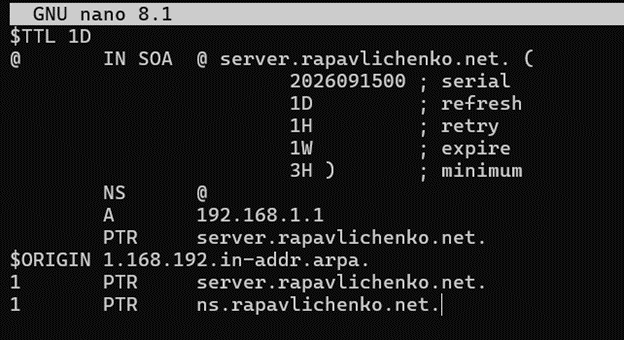

## Настройка SELinux

Восстановлены контексты файлов и включён параметр `named_write_master_zones`.

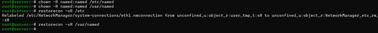

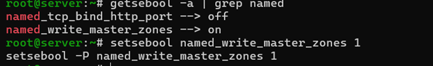